# BIOST 561: Homework 2

Due date: 7:00pm on Monday, April 22nd, 2024

# Q0: Setting up your `UWBiost561` package

**Question 0A**: Completed

**Question 0B**: Completed

**Question 0C**: Completed

```r
library(bookdown)
library(tidyverse)
library(ggplot2)
```

**Question 0D**: Completed

# Q1: Practice using tibbles

**Intent**: This question is to give you some basic practice using tibbles (and the tidyverse way of analyzing data, overall).

For this question, we’ll be using two datasets that collect various statistics of countries over many years. The first dataset is the `gt` package (see https://search.r-project.org/CRAN/refmans/gt/html/countrypops.html), and has been formatted specifically for this homework. It can be loaded in the following code:

```r
# import data
country_population <- readr::read_csv("https://raw.githubusercontent.com/linnykos/561_s2024_public/main/HW2_files/country_population.csv")

# present 5 random rows
country_population[sample(nrow(country_population), 5),]
```

```
#> # A tibble: 5 × 4
#>   iso3c country     year population
#>   <chr> <chr>      <dbl>      <dbl>
#> 1 ARM   Armenia     2009    2964296
#> 2 EST   Estonia     1963    1258857
#> 3 SYC   Seychelles  1961      42889
#> 4 UKR   Ukraine     2015   45154036
#> 5 IND   India       1995  964279129
```

`country_population` contains the following columns:

- `iso3c`: Three-letter country code (see https://en.wikipedia.org/wiki/ISO_3166-1_alpha-3)
- `country`: Country name
- `year`: Year the statistic is collected
- `population`: Population, based on the World Bank estimate

The next dataset is from https://paldhous.github.io/NICAR/2017/r-analysis.html, and has also been formatted specifically for this homework. It can be loaded in the following code:

```r
# load data
country_birth <- readr::read_csv("https://raw.githubusercontent.com/linnykos/561_s2024_public/main/HW2_files/country_birth.csv")

# select 5 random rows
country_birth[sample(nrow(country_birth), 5),]
```

```
#> # A tibble: 5 × 5
#>   iso3c  year life_expect birth_rate neonat_mortal_rate
#>   <chr> <dbl>       <dbl>      <dbl>              <dbl>
#> 1 FRA    2012        82.0       12.6                2.2
#> 2 ESP    2005        80.2       10.6                3.5
#> 3 NAM    2014        64.7       29.7               16.1
#> 4 GIB    1994        NA         NA                 NA
#> 5 SVN    1992        73.3       10                  4.9
```

`country_birth` contains the following columns:

- `iso2c`: Two-letter country code
- `iso3c`: Three-letter country code
- `year`: Year the statistic is collected
- `life_expect`: Life expectancy at birth, in years.
- `birth_rate`: Live births during the year per 1,000 people
- `neonat_mortal_rate`: Neonatal mortality rate: babies dying before reaching 28 days of age per 1,000 live births in a given year

This question will allow you to practice basic data manipulation of these two `tibble` objects.

**Question 1A**: We will be manipulating the `country_population` data in this question. Your goal is the following: Select only rows for years between 1990 and 2010 (inclusive). Then, compute the mean population across all the years of a country for each country (defining a new variable called `mean_population`, via the `group_by()` and `summarize()` functions).

```r
country_population <- country_population %>%
  dplyr::filter(1990 <= year & year <= 2010) %>%
  group_by(iso3c, country) %>%
  summarize(mean_population = mean(population))

head(country_population)
```

```
#> # A tibble: 6 × 3
#> # Groups:   iso3c [6]
#>   iso3c country              mean_population
#>   <chr> <chr>                          <dbl>
#> 1 ABW   Aruba                         85839.
#> 2 AFG   Afghanistan                19819866.
#> 3 AGO   Angola                     16829911.
#> 4 ALB   Albania                     3095489.
#> 5 AND   Andorra                       67825.
#> 6 ARE   United Arab Emirates        3858774.
```

**Question 1B**: We will be manipulating the `country_birth` data in this question. Your goal is the following: Select only rows for years between 1990 and 2010 (inclusive), keep the `iso3c`, `year`, `life_expect` columns, and then drop all rows with any `NA` in any of the 3 columns. Then, compute the minimum and maximum life expectancy (named as new columns called `min_life_expect` and `max_life_expect`) for each country across all the years (via the `summarize()` function), and finally, create a new column called `range_life_expect` that is the number of years between `min_life_expect` and `max_life_expect` for each country (via the `mutate()` function).

```r
country_birth <- country_birth %>%
  filter(1990 <= year & year <= 2010) %>%
  select(iso3c, year, life_expect) %>%
  drop_na %>%
  group_by(iso3c) %>%
  summarize(min_life_expect = round(min(life_expect), 1),
            max_life_expect = round(max(life_expect), 1),
            range_life_expect = round(max_life_expect - min_life_expect, 2))

head(country_birth)
```

```
#> # A tibble: 6 × 4
#>   iso3c min_life_expect max_life_expect range_life_expect
#>   <chr>           <dbl>           <dbl>             <dbl>
#> 1 ABW              73.4            75                 1.6
#> 2 AFG              49.9            59                 9.1
#> 3 AGO              41.1            50.7               9.6
#> 4 ALB              71.9            77                 5.1
#> 5 ARE              71.7            76.7               5
#> 6 ARG              71.5            75.5               4
```

**Question 1C**: We will now combine `country_population` and `country_birth` via a join. Specifically, using an `inner_join()` function, combine both these datasets by the `iso3c` variable, and call the new `tibble` object as `country_both`. Print out the first 10 rows of `country_both`. How many rows and columns are in `country_both`?

```r
country_both <- inner_join(country_population, country_birth, by="iso3c")
head(country_both, 10)
```

```
#> # A tibble: 10 × 6
#> # Groups:   iso3c [10]
#>    iso3c country              mean_population min_life_expect max_life_expect
#>    <chr> <chr>                          <dbl>           <dbl>           <dbl>
#>  1 ABW   Aruba                         85839.            73.4            75
#>  2 AFG   Afghanistan                19819866.            49.9            59
#>  3 AGO   Angola                     16829911.            41.1            50.7
#>  4 ALB   Albania                     3095489.            71.9            77
#>  5 ARE   United Arab Emirates        3858774.            71.7            76.7
#>  6 ARG   Argentina                  36972314.            71.5            75.5
#>  7 ARM   Armenia                     3211816.            67.7            74.2
#>  8 ATG   Antigua and Barbuda           74385.            71.2            75.3
#>  9 AUS   Australia                  19200991.            77              81.7
#> 10 AUT   Austria                     8057573.            75.6            80.6
#> # ℹ 1 more variable: range_life_expect <dbl>
```

```r
dim(country_birth) # 203 rows, 4 columns
```

```
#> [1] 203   4
```

# Q2: Practice using ggplot via scatterplots and facets

**Intent**: This question is to give you some basic practice using ggplot, mainly plotting scatterplots and faceting the plots.

For this question, we’ll be using a dataset about the penguins from the Palmer Archipelago from https://allisonhorst.github.io/palmerpenguins/reference/penguins.html. We’ve processed it lightly for this homework.

```r
# load data
penguins <- readr::read_csv("https://raw.githubusercontent.com/linnykos/561_s2024_public/main/HW2_files/palmerpenguins.csv")
head(penguins)
```

```
#> # A tibble: 6 × 8
#>   species island    bill_length_mm bill_depth_mm flipper_length_mm body_mass_g
#>   <chr>   <chr>              <dbl>         <dbl>             <dbl>       <dbl>
#> 1 Adelie  Torgersen           39.1          18.7               181        3750
#> 2 Adelie  Torgersen           39.5          17.4               186        3800
#> 3 Adelie  Torgersen           40.3          18                 195        3250
#> 4 Adelie  Torgersen           36.7          19.3               193        3450
#> 5 Adelie  Torgersen           39.3          20.6               190        3650
#> 6 Adelie  Torgersen           38.9          17.8               181        3625
#> # ℹ 2 more variables: sex <chr>, year <dbl>
```

You can see its original documentation for describing the variables in the dataset.

The following code makes a basic scatter plot. We will be improving this plot over the following sub-questions.

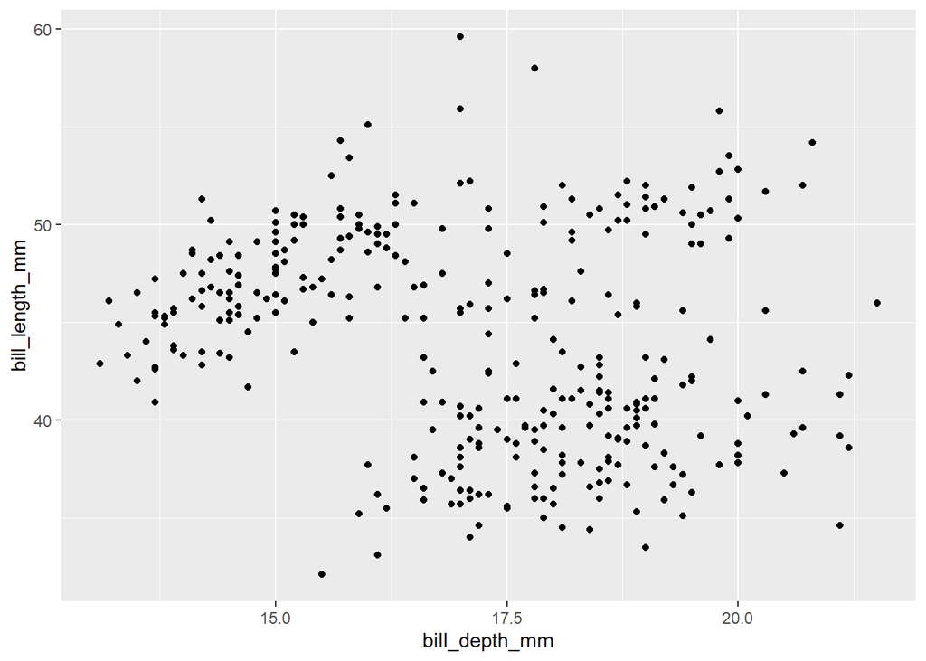

```r
penguins %>%
  ggplot(aes(x = bill_depth_mm, y = bill_length_mm)) +
  geom_point()
```

**Question 2A**: With the `penguins` dataset, change the x-axis label and y-axis label to say `Bill Depth (mm)` and `Bill length (mm)` respectively, as well as the title of the plot to write `Relation among ??? penguins`, where you use code to count how many rows there are in `penguins` automatically (in place of `???`). Additionally, color each point based on their `species`, where `Adelie` has the color `cornflowerblue`, `Chinstrap` has the color `coral2`,and `Gentoo` has the color `goldenrod3`.

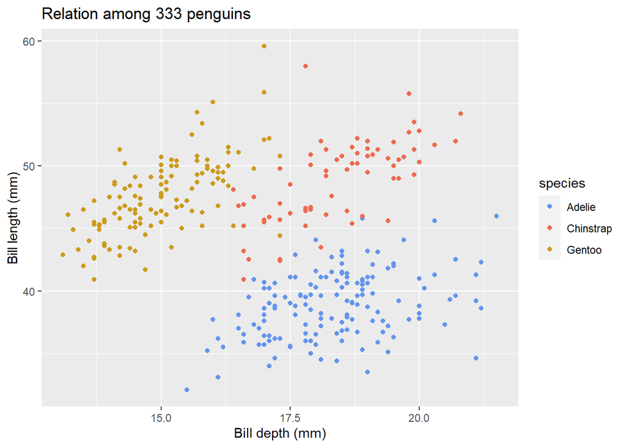

```r
penguins %>%
  ggplot(aes(x = bill_depth_mm, y = bill_length_mm, color=species)) +
  geom_point() +
  xlab("Bill depth (mm)") + ylab("Bill length (mm)") +
  labs(title = paste("Relation among", nrow(penguins), "penguins")) +
  scale_color_manual(values = c("cornflowerblue", "coral2", "goldenrod3"))
```

**Question 2B**: We now will make the following changes: 1) we will facet the scatterplot based on the `species`, 2) we will add a linear regression fit on each `species` (regression `bill_length_mm` onto the `bill_depth_mm`) and plot the linear regression fit, and 3) changing the transparency of the points to be 50% transparent (i.e., `alpha=0.5`).

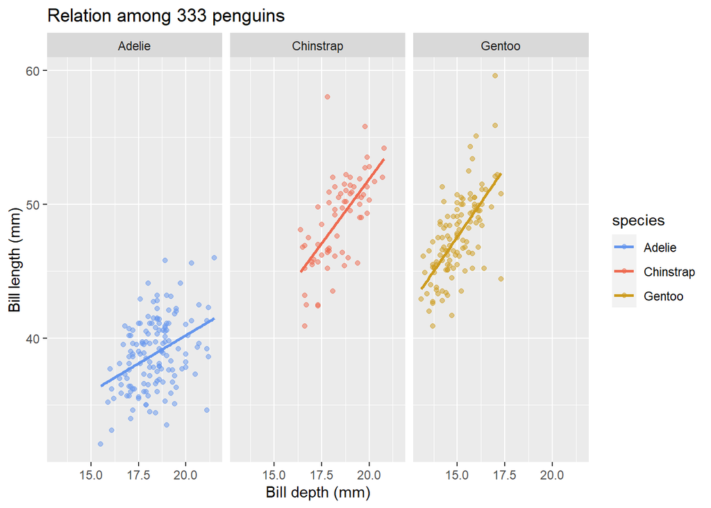

```r
penguins %>%
  ggplot(aes(x = bill_depth_mm, y = bill_length_mm, color=species)) +
  geom_point(alpha = 0.5) +
  geom_smooth(method = "lm", se = F) +
  facet_wrap(vars(species)) +
  xlab("Bill depth (mm)") + ylab("Bill length (mm)") +
  labs(title = paste("Relation among", nrow(penguins), "penguins")) +
  scale_color_manual(values = c("cornflowerblue", "coral2", "goldenrod3"))
```

# Q3: Practice using ggplot via heatmaps

**Intent**: This question is to give you some basic practice using ggplot, mainly plotting heatmaps. You will also see this `generate_random_graph()` function again in future homeworks.

**Run the following code to load the `generate_random_graph()`, which generates `adj_mat`, a random adjacency matrix (corresponding to a graph with 20 nodes). Each row/column of `adj_mat` corresponds to one of the 20 nodes, and a value of 0 or 1 denotes the lack or presence of an edge between two nodes, respectively.**

```r
source("https://raw.githubusercontent.com/linnykos/561_s2024_public/main/HW2_files/random_graph_functions.R")
```

```r
set.seed(0)
result <- generate_random_graph(n= 20, clique_fraction = 0.5, density_low = 0.1)
adj_mat <- result$adj_mat
dim(adj_mat)
```

```
#> [1] 20 20
```

```r
adj_mat[1:5,1:5]
```

```
#>      [,1] [,2] [,3] [,4] [,5]
#> [1,]    1    0    1    0    0
#> [2,]    0    1    1    1    1
#> [3,]    1    1    1    0    0
#> [4,]    0    1    0    1    0
#> [5,]    0    1    0    0    1
```

**Question 3A**: Read how the provided `generate_random_graph()` works (either typing `generate_random_graph` into the R console or reading the code at https://raw.githubusercontent.com/linnykos/561_s2024_public/main/HW2_files/random_graph_functions.R). In three to five sentences, describe what `generate_random_graph()` does.

**After ensuring all the arguments are valid, it generate a non-symmetric matrix with randomly placed 0’s and 1’s. Then the matrix is added to its transpose to be made symmetric and corrected so all values are 0 or 1. Then a clique (fully connected sub-matrix) is made and the nodes randomized. This is returned alongside the matrix’s reverse order.**

**Question 3B**: You will now write code to produce a heatmap to visualize `adj_mat`. Before this can happen, though, you need one more function to convert `adj_mat` into a “long form,” which is a necessity when visualizing any plot as a heatmap in ggplot. See https://r-graph-gallery.com/heatmap.html. This is done via the provided `pivot_longer_heatmap()` function:

```r
mat_long <- pivot_longer_heatmap(adj_mat)
mat_long
```

```
#> # A tibble: 400 × 3
#>        X     Y Value
#>    <int> <dbl> <dbl>
#>  1     1     1     1
#>  2     1     2     0
#>  3     1     3     1
#>  4     1     4     0
#>  5     1     5     0
#>  6     1     6     1
#>  7     1     7     0
#>  8     1     8     0
#>  9     1     9     0
#> 10     1    10     0
#> # ℹ 390 more rows
```

Read what the `pivot_longer_heatmap()` function does (either typing `pivot_longer_heatmap` into the R console or reading the code at https://raw.githubusercontent.com/linnykos/561_s2024_public/main/HW2_files/random_graph_functions.R). In three to five sentences, describe what `pivot_longer_heatmap()` does. Specifically, how does the output of `pivot_longer_heatmap()` relate to `adj_mat`?

(Hint: For this question, it might be helpful to manually run the function line-by-line in your R console to see what each line of code does. The hardest part of this question will be understanding what the `pivot_longer` function does. Look at the documentation of this function via `?tidyr::pivot_longer`. It might also be helpful to recall, in your R console, what the values of `adj_mat[1,1]`, `adj_mat[1,2]`, `adj_mat[1,3]`, … are. How do they look similar to rows in `mat_long`?)

**Question 3C**: Now you are ready to write code to visualize `mat_long` as a heatmap. Write code using ggplot’s functions to do this. You want to color all the `0` values as `palegoldenrod` and all the `1` values as `coral2`. Please set the aspect ratio of this plot to be 1:1 (i.e., your “boxes” are squares) via the `coord_fixed()` function.

In two to four sentences, describe how the plot you made relates to `adj_mat`.

**The plot is a visualization of the adjacency matrix, so cells at location (X,Y) indicate whether node X and node Y share an edge. Cell values of 1 indicate an edge is present, 0 indicate no edge. Note that diagonal cells at locations (X,X) have cell values of 1.**

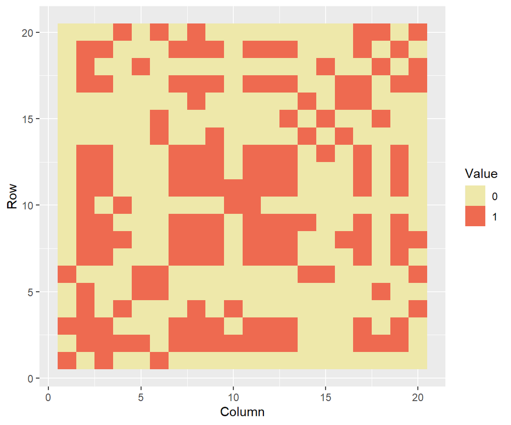

```r
mat_long %>%
  mutate(Value = as.factor(Value)) %>%
  ggplot(aes(x=X, y=Y, fill=Value)) +
  geom_tile() +
  scale_fill_manual(values = c("palegoldenrod", "coral2")) +
  xlab("Column") + ylab("Row")
```

**Question 3D**: Congratulations! You have a working pipeline to visualize any adjacency matrix. For this last question, we will combine all your functions to visualize the following:

```r
adj_mat2 <- result$adj_mat[result$rev_order, result$rev_order]
```

You can double-check yourself to see that this line of code only permutes the rows and columns. The actual “graph” does not change (since the ordering of the rows/columns is arbitrary).

Use the provided `pivot_longer_heatmap()` function and your code from Question 3C to visualize `adj_mat2`. (You are mainly copy-pasting the code from your previous questions but now applying it to `adj_mat2`.)

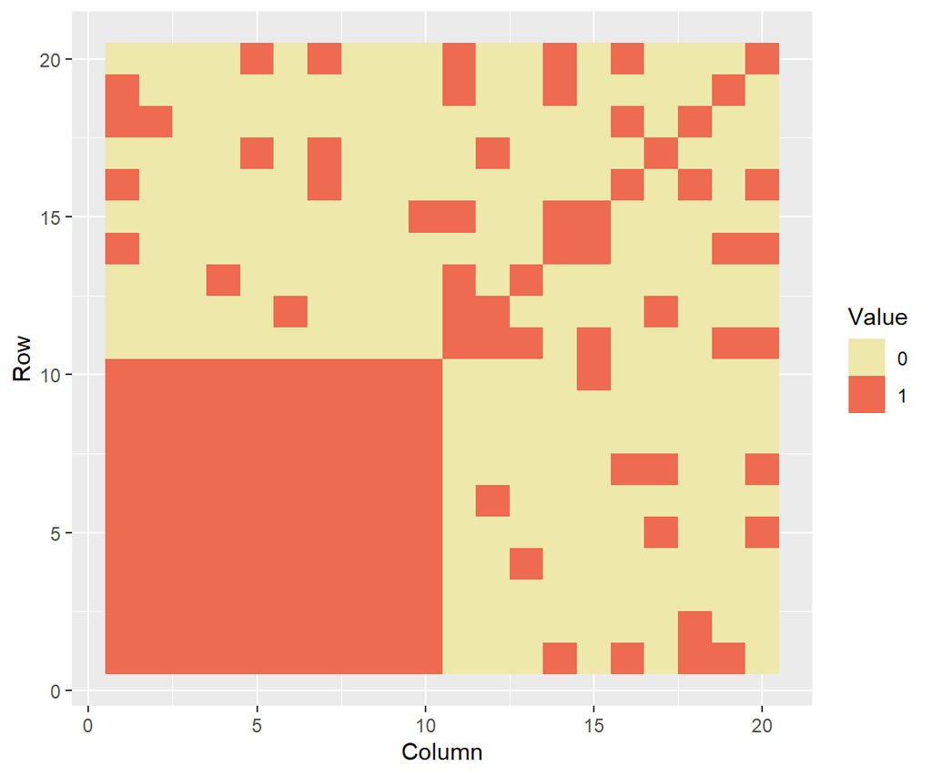

```r
pivot_longer_heatmap(adj_mat2) %>%
  mutate(Value = as.factor(Value)) %>%
  ggplot(aes(x=X, y=Y, fill=Value)) +
  geom_tile() +
  scale_fill_manual(values = c("palegoldenrod", "coral2")) +
  xlab("Column") + ylab("Row")
```

You will see a dense set of red blocks in the bottom-left corner of the heatmap. In two sentences, what does this plot tell us about `adj_mat2`, and in turn, about `adj_mat`? (Hint: Question 4 will give you some context to answer this question.)

**This block of red is from a fully connected sub-network (aka clique), as visualized in a re-arranged adjacency matrix.**

# Q4: Planning for the next homework – thinking how to test a function

**Intent**: This question will get you started on how to think about testing a function.

Question 3 demonstrates a “planted clique” – there might be a clique in a random graph (i.e., a collection of connected nodes). This clique might not be evident at first glance (as demonstrated in Question 3C), but when you permute the rows and columns (as done in Question 3D), the clique is quite apparent. (In Lecture 4, we will go over the basics of thinking about graphs and adjacency matrices. Please watch the Panopto. recording on Canvas if you want some context.)

Suppose your teammate gave you a function to find the **maximal clique** in an adjacency matrix (i.e., the set of nodes that forms the largest clique). You are not told the typical size and characteristics of these adjacency matrices beforehand. Your job is to make sure this function is correct since you and your teammate are about to give this function to your manager, who will then give it to another division in your company to use. Your performance review will depend highly on whether or not other people in your company can reliably use your function.

In a short paragraph, write down ways to ensure your teammate’s function is “correct.” Please list at least four different ways you can test this function. You can interpret this notion of “correct” very liberally – this question is purposely framed to be open-ended.

**First and foremost, I would test the function’s accuracy with some small to moderately-sized example matrices. I would test the function’s “correctness” by assessing its time and space complexity (how fast/efficient it is and how much computational space it takes up/computational tasks it creates)- I remember these as important metrics from my Computer Science courses. Finally, I might consider the function’s readability as a relevant consideration, because if the code is a gargled mess people in the company will have difficulty using it.**

# Q5: Feedback (Optional)

This “question” is an additional way for students to communicate with instructors. You could include positive feedback about topics you enjoyed learning in this module, critiques about the course difficulty/pacing, or some questions/confusions you had about course material. Your feedback can help shape the course for the rest of this quarter and future years. Please be mindful and polite when providing feedback. You may leave this question blank.

- Question 1B: Adding the column for range doesn’t require `mutate()`, we can do it right in `summarize()`! (so long as it’s defined last)
- Question 2B: Did you intend for `alpha` to show up in the key? Assigning it a value outside `aes()` prevents it from showing there :-)